# 🎓 Tutorial: the Northeast Pacific (FAO area 67) from zero to a report

## 8. 🔍 Data quality, diversity and fleets

### 8.1 How good are the data? `data_quality()`

```r
quality <- data_quality(area67)
```

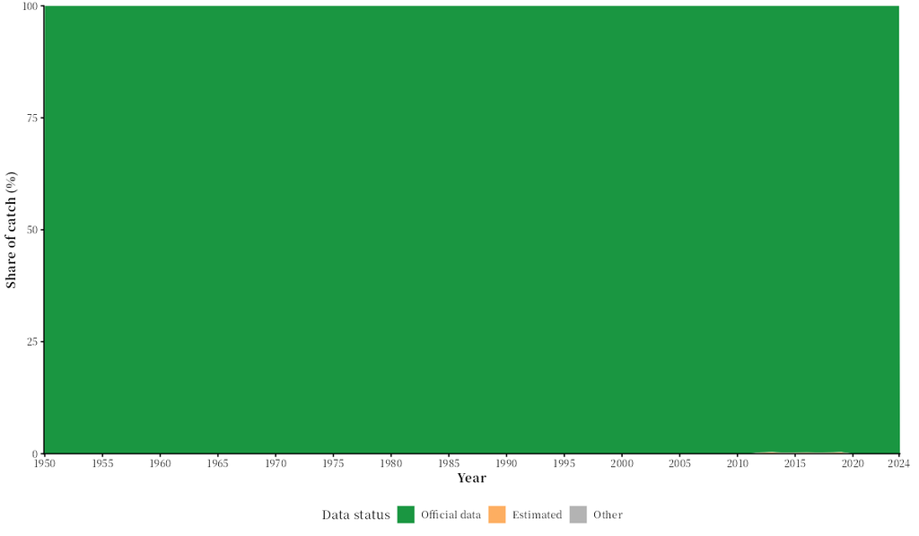

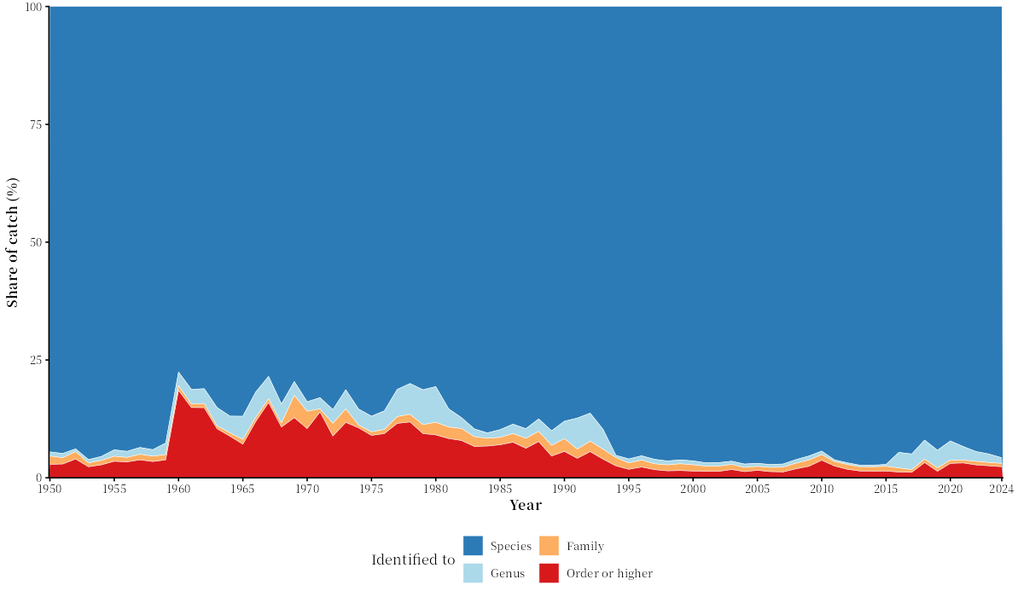

🔎 *How to read them.* `_taxon_share`: the share of the catch identified to species, genus, family, or only to order or higher (e.g. “Marine fishes nei”). `_status_share`: the share reported officially by countries and the share estimated by FAO or the country.

*What it shows for area 67.* In 2024, 95.7% of the catch was identified to species, only 2.4% to order or higher, and 100.0% was official data reported by the countries. Few areas have data this good: the species charts above describe nearly the whole catch, and a change in a species is unlikely to be a change in reporting.

### 8.2 Diversity and concentration: `diversity_concentration()`

```r
div <- diversity_concentration(area67)
```

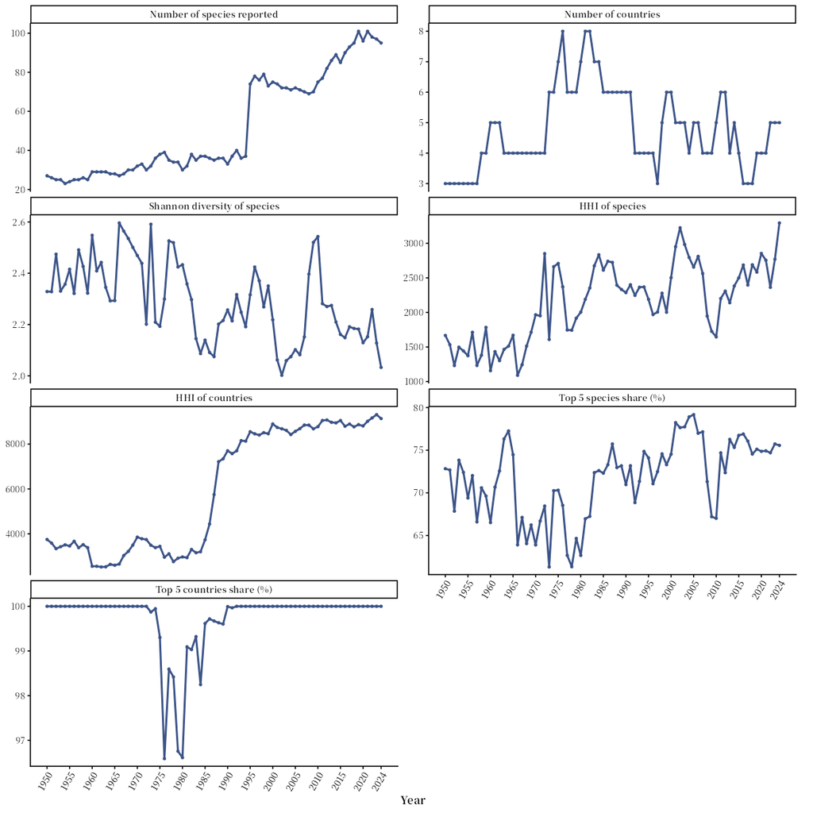

🔎 *How to read it.* Seven indicators, one per panel: the number of species items and of countries reporting, the Shannon diversity of the species, the Herfindahl-Hirschman index (HHI) of the species and of the countries, and the share of the five largest species and countries. The HHI goes from near 0 (catch spread over many) to 10 000 (one takes all); above 2 500 is “highly concentrated”.

*What it shows for area 67.* In 2024, 95 species items and 5 countries reported catch. Both indices are above 2 500: the HHI of the countries was 9135, close to its maximum, because the United States takes almost everything, and the HHI of the species was 3295, because of the pollock. The area has many species, but its catch depends on one country and one species.

### 8.3 Who fishes: `country_group_summary()` and `coastal_distant()`

```r
income <- country_group_summary(area67)
fleets <- coastal_distant(area67)
```

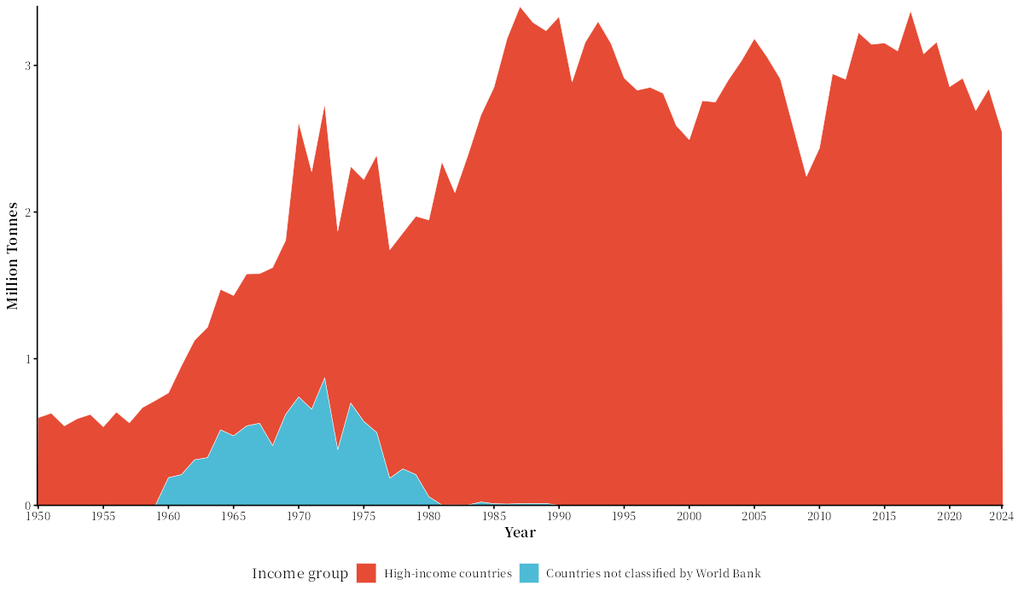

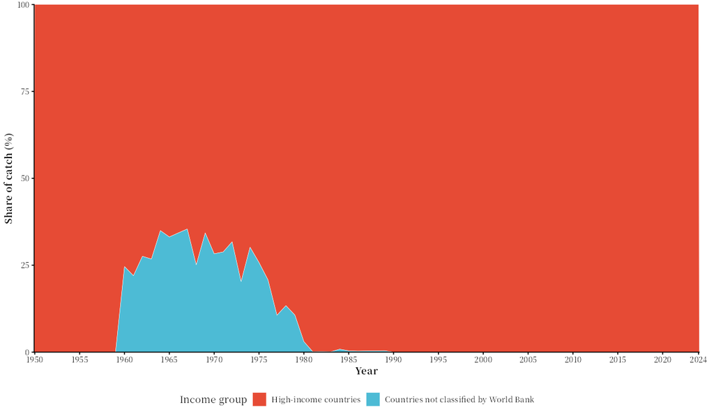

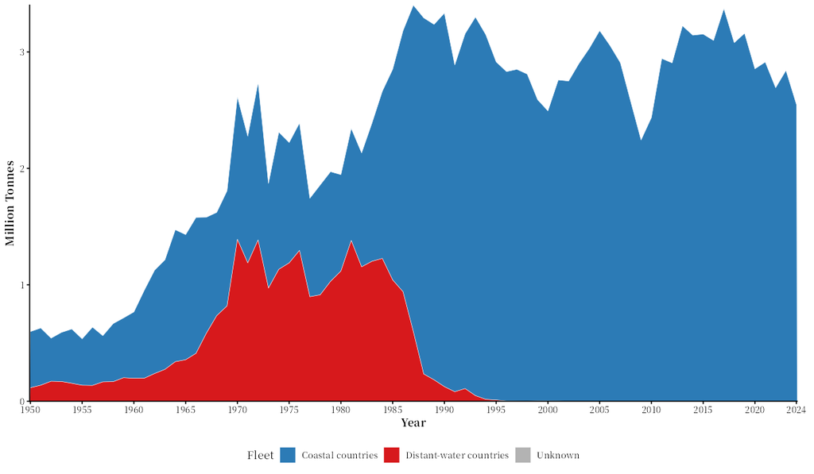

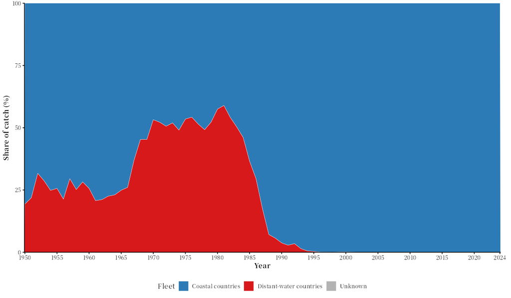

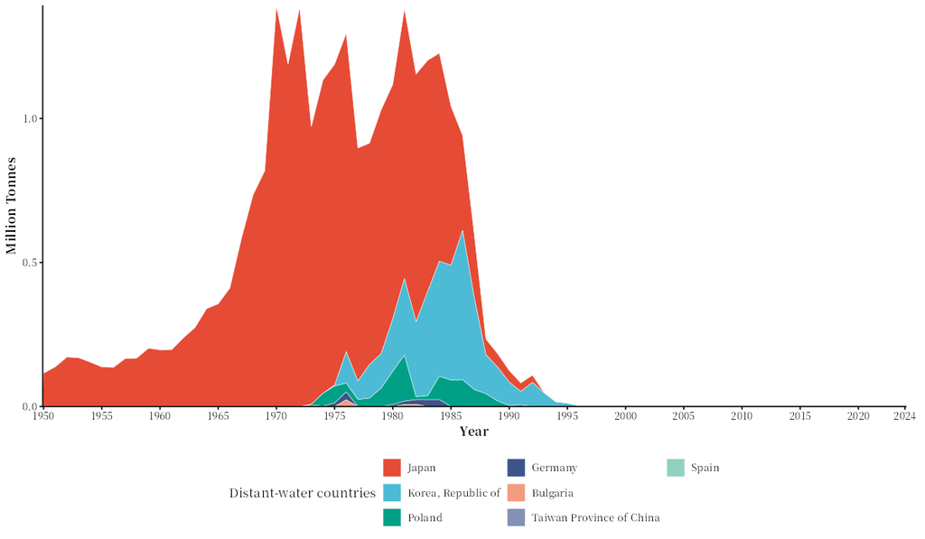

🔎 *How to read them.* `country_income`: the catch by World Bank income group of the countries. `coastal_distant`: the catch of **coastal countries** (whose territory borders the area) and of **distant-water countries**, from the FAO area boundaries and country outlines.

*What it shows for area 67.* Nearly all the catch is taken by high-income countries; the “not classified” part of the 1960s and 1970s is the USSR, which no longer exists. The distant-water countries (Japan, the Republic of Korea, Poland and others) took 26% of the catch in 1960 and up to 59% in 1981; their share fell below 1% in 1994 and has stayed there. Note that the USSR and the Russian Federation count as coastal, because part of the Russian coast on the Bering Sea borders the area: the foreign share of the catch before 1990 was even larger than the distant-water share.

## 9. 🔬 Methods from the literature

These analyses follow published methods; 🔬 Shocks, collapses, synchrony and fleets explains each in detail.

### 9.1 Catch shocks: `catch_shocks()`

```r
shocks_country <- catch_shocks(area67)
shocks_species <- catch_shocks(area67, by = "species", label = "area67_species")
```

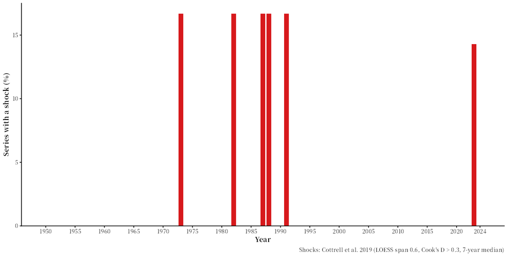

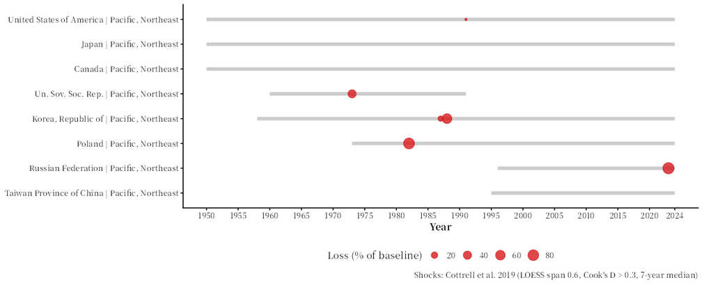

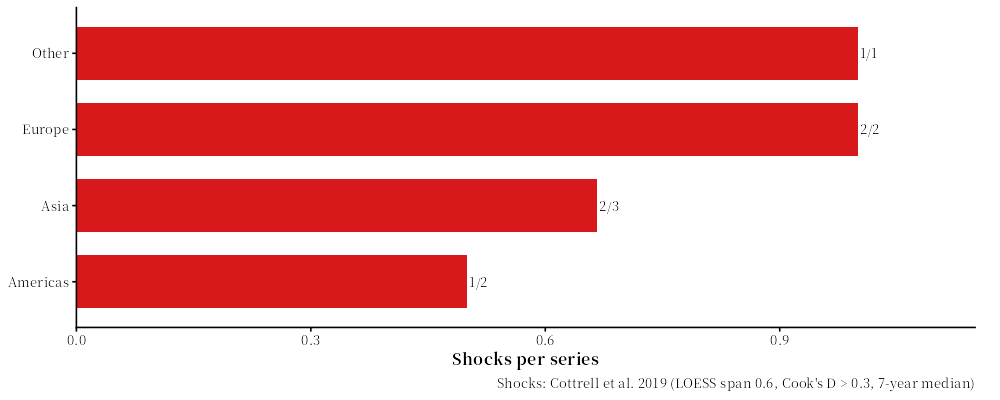

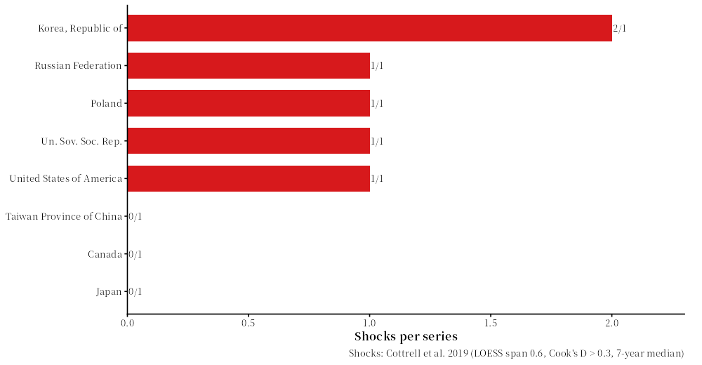

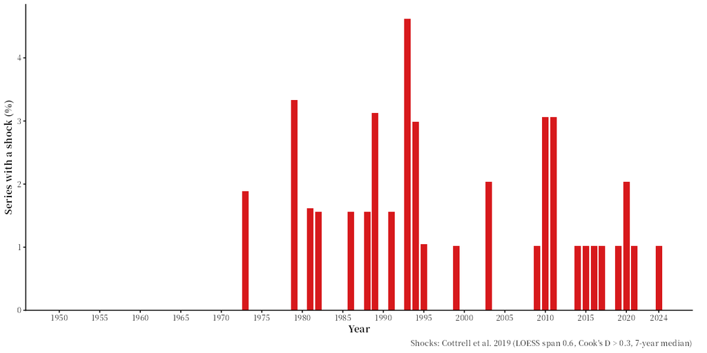

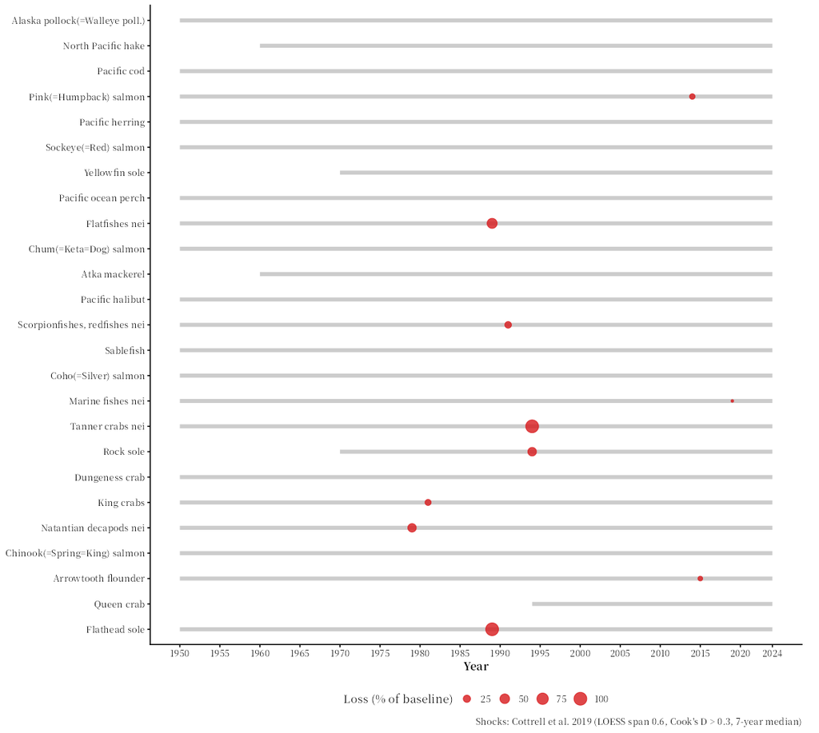

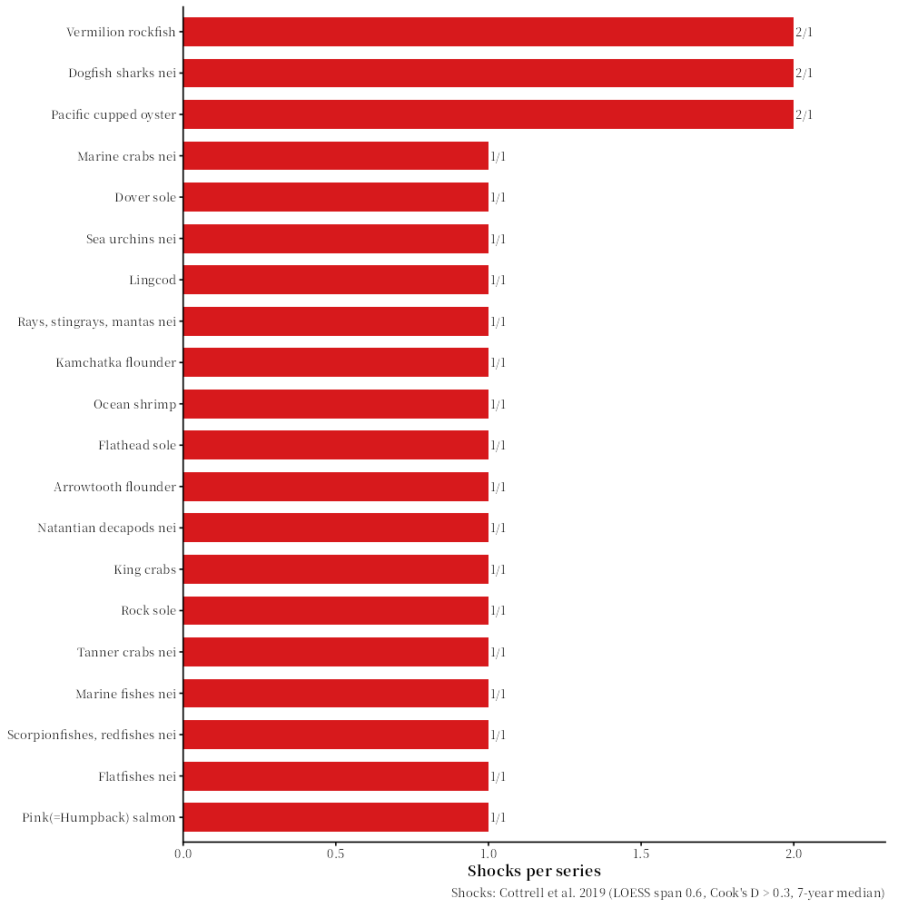

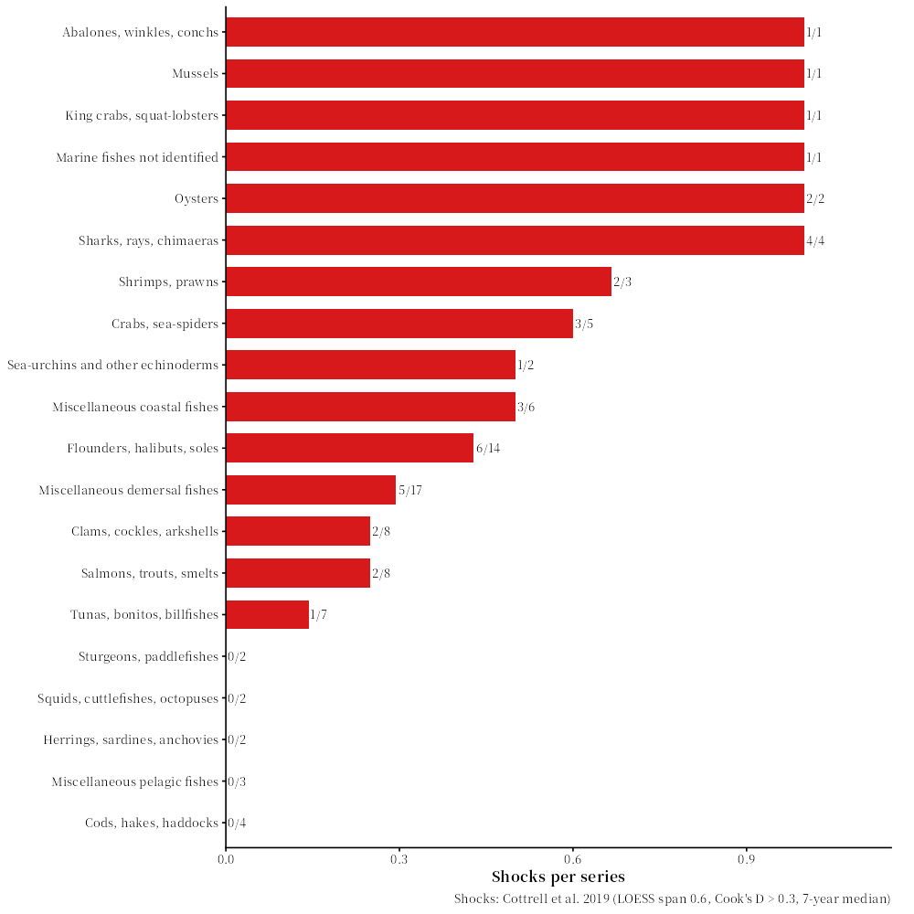

🔎 *How to read them.* A **shock** is a year in which the catch of a series fell far below what its recent years predicted (Cottrell et al. 2019). The bar chart gives the percentage of series with a shock in each year; `_series` shows the series with their shocks, `_by_country` / `_by_continent` count them by group.

*What it shows for area 67.* By country (`by = c("country", "area")`, the default), area 67 has only 8 series, so each shock is a large percentage and the chart is coarse. By species there are 98 series and 35 shocks, a more informative picture for one area. **Choose the series to fit the question**: countries for national food supply, species for ecology.

### 9.2 Fishery collapses: `collapse_analysis()`

```r
set.seed(1)   # the comparison with random series uses random numbers
collapses <- collapse_analysis(area67)
show_table(collapses$summary)
```

[output not shown]

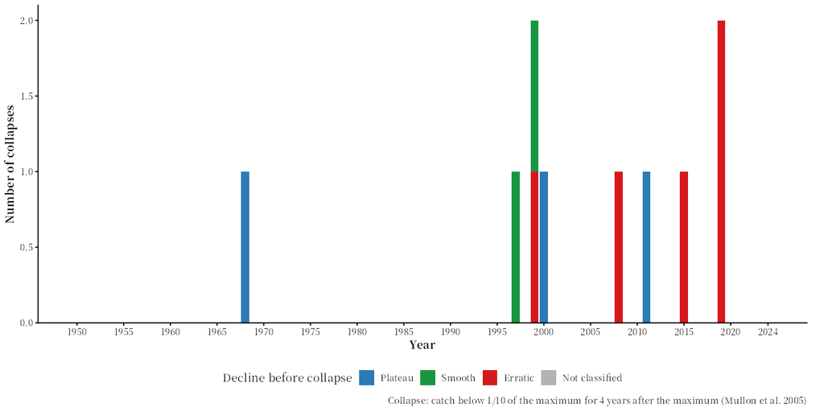

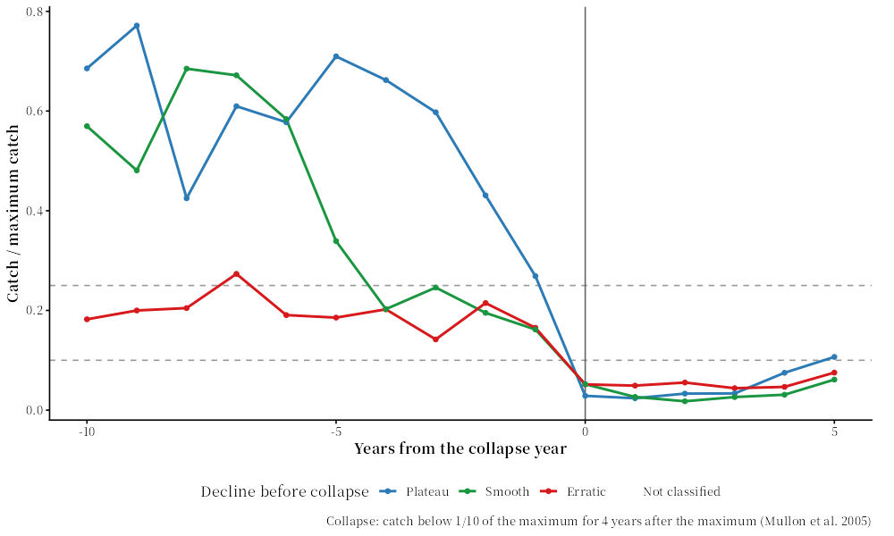

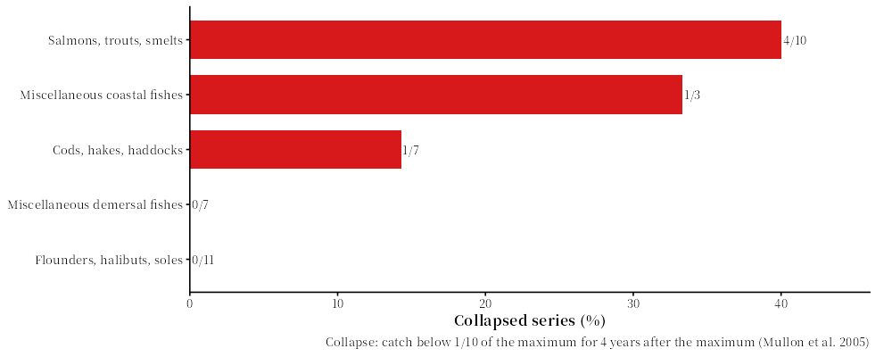

🔎 *How to read it.* A series (one species by one country) has **collapsed** when, after its maximum, its catch stays below a tenth of the maximum for four years (Mullon et al. 2005). The bars count collapses by year and by the shape of the decline before them (plateau, smooth or erratic). The function repeats the analysis on random series without trend, because random ups and downs alone produce some “collapses” (Wilberg and Miller 2007): only the excess over that null model is informative.

*What it shows for area 67.* 10 of the 50 series collapsed (20%), against 21% of the random series. That is about what random variability alone produces, so the collapses of area 67 are, as a whole, no evidence of a fishery-wide problem; look at the individual series instead. This is why the null model matters: without it, 20% of the series “collapsed” would sound alarming.

### 9.3 Synchrony and the portfolio effect: `catch_synchrony()`

```r
sync <- catch_synchrony(area67)
```

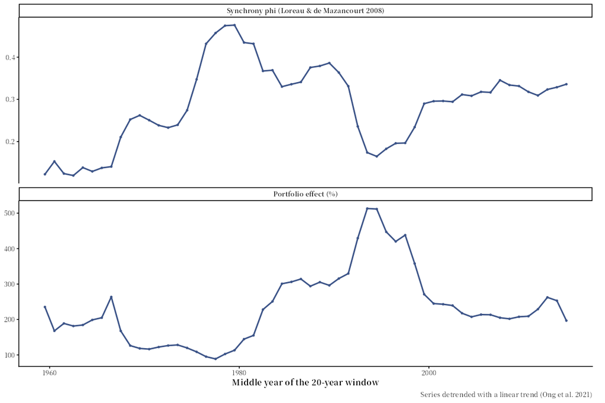

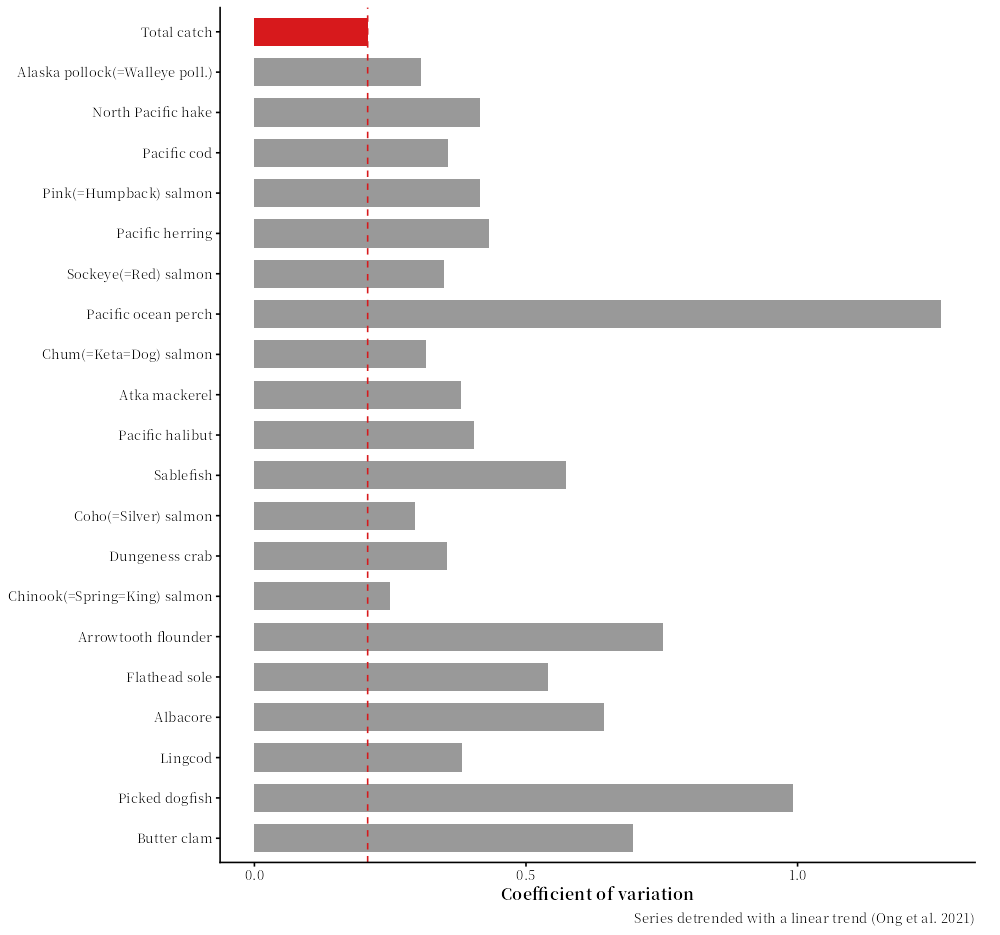

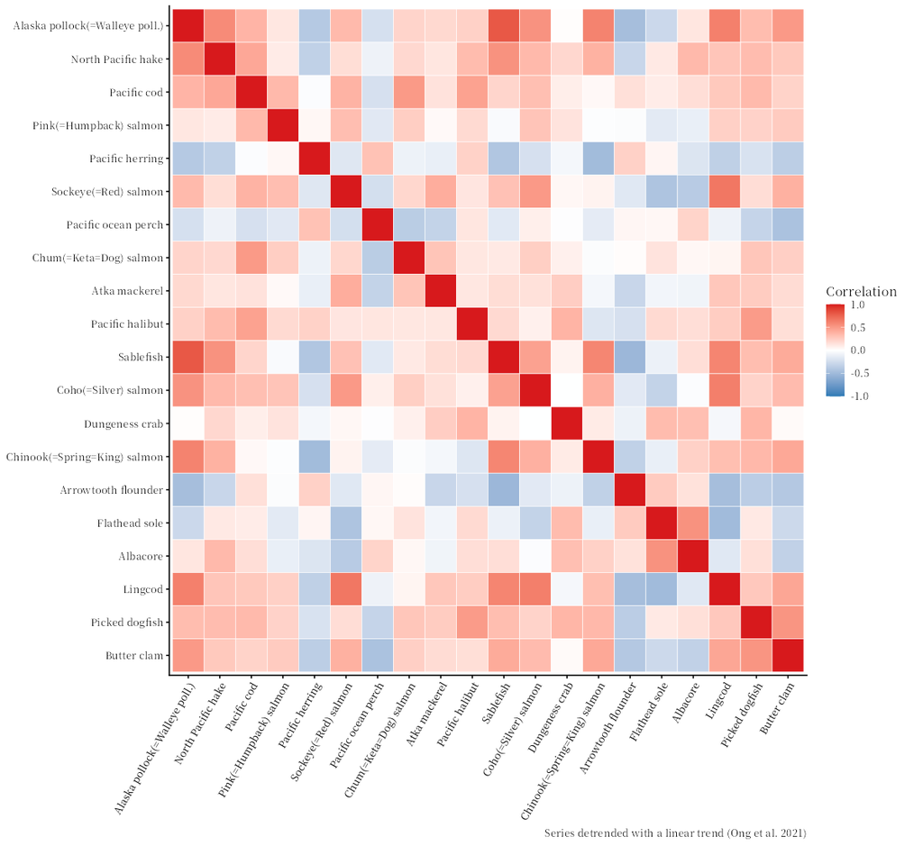

🔎 *How to read them.* `_cv`: the coefficient of variation (year-to-year variability) of each species and, in red, of the total catch. `_correlation`: how the species vary together. The synchrony index φ is 0 when species compensate each other and 1 when they rise and fall together (Loreau and de Mazancourt 2008).

*What it shows for area 67.* φ = 0.3: the total catch varies (CV 0.21) much less than its species (mean CV 0.54): the species are on average 161% more variable than their total. This **portfolio effect** means that when one species declines, others take its place. Among the main species in the chart, the Pacific ocean perch is by far the most variable, the mark of its boom and bust.

### 9.4 Pelagic to demersal ratio: `pelagic_demersal()`

```r
pd <- pelagic_demersal(area67)
show_table(pd$decades[, c("period", "pd_mean", "pd_min", "pd_max")])
```

[output not shown]

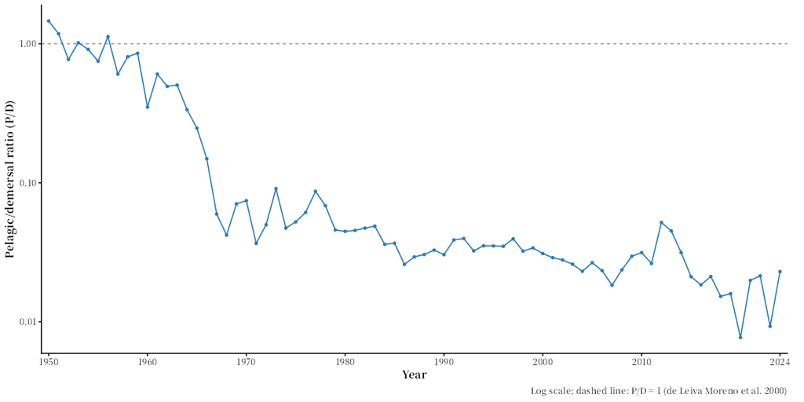

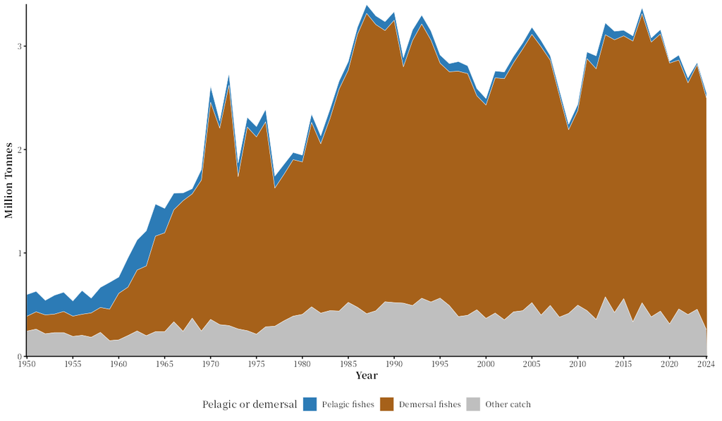

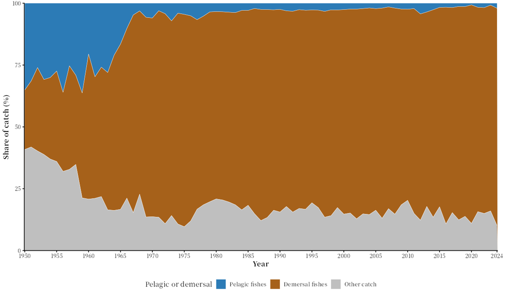

🔎 *How to read them.* P/D is the catch of small pelagic fishes divided by the catch of demersal fishes and crustaceans (Caddy 1993; de Leiva Moreno et al. 2000), on a log scale; the dashed line is P/D = 1. In semi-enclosed seas a rising P/D has been linked to nutrient enrichment; in open areas it mostly follows what the fleets target.

*What it shows for area 67.* P/D fell from 0.95 in the 1950s to 0.016 in the 2020s. It does not mean the sea lost its nutrients: the herring fisheries shrank while the trawl fisheries for groundfish grew, so the ratio tells the history of the fishery.

### 9.5 A distant-water fleet: `distant_water_profile()`

```r
japan_dw <- distant_water_profile("Japan")
```

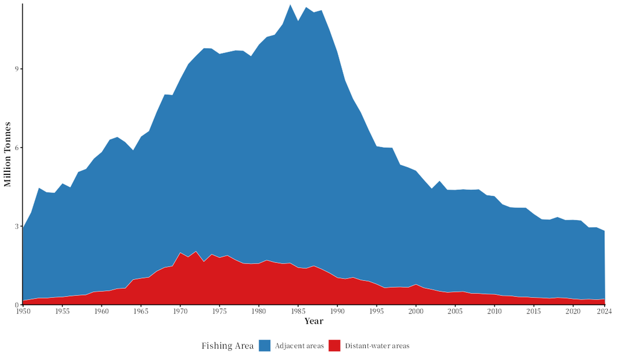

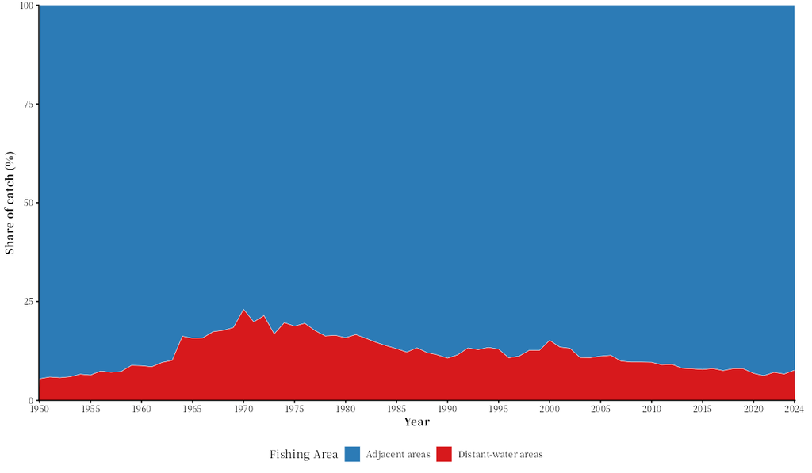

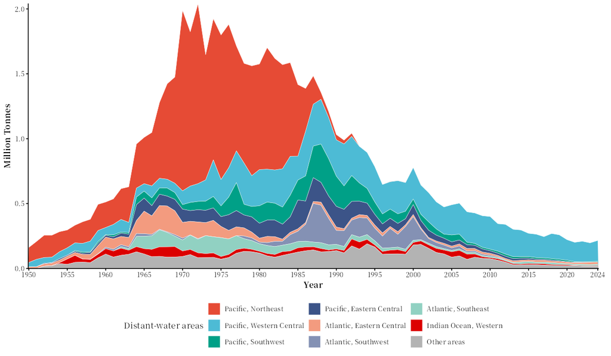

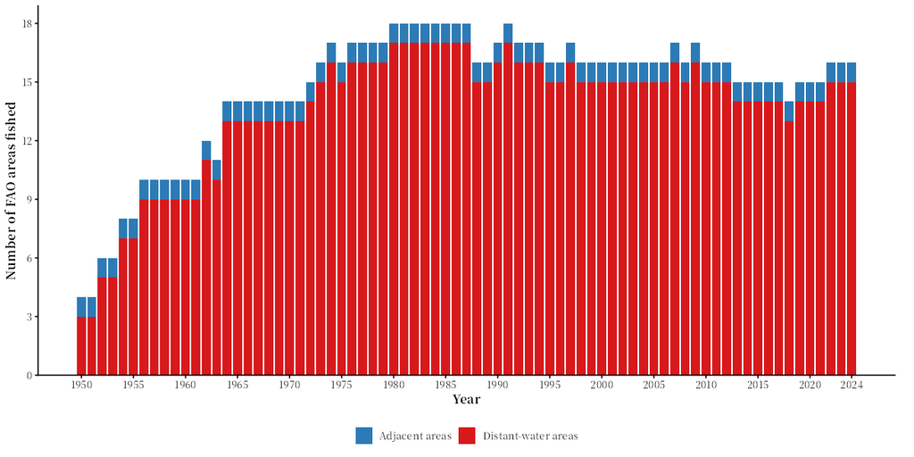

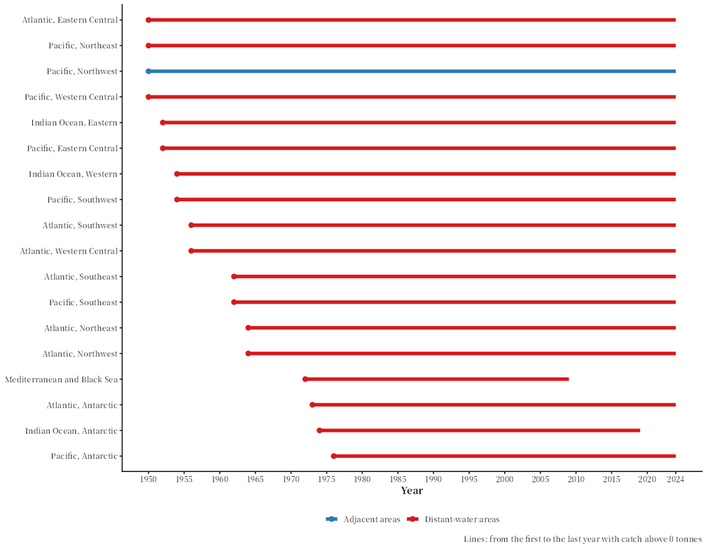

🔎 *How to read them.* The catch of one country in the FAO areas it borders (“adjacent”) and in the others (“distant-water”), the share of distant-water catch, the number of areas fished each year and when it entered each area (Swartz et al. 2010).

*What it shows.* Japan’s only adjacent area is area 61. Its distant-water share rose to 23.1% in 1970, when it fished 13 distant FAO areas; in that year area 67 alone gave 1.39 million t, or 70% of its distant-water catch. The 200-mile zones of the late 1970s closed the richest of these waters, and the share was 7.6% in 2024. Area 67 and Japan show the two sides of the same change.

## 10. 🌡️ Species traits and temperature

### 10.1 FishBase traits: `fishbase_match()`

```r
traits <- fishbase_match(area67, version = "builtin")
show_table(traits[, c("species_en", "catch_pct", "match_type", "trophic_level", "temp_pref_mean")], n = 8)
```

| species_en | catch_pct | match_type | trophic_level | temp_pref_mean |
| --- | --- | --- | --- | --- |
| Alaska pollock(=Walleye poll.) | 43.51 | exact | 3.57 | 1.6 |
| North Pacific hake | 7.67 | exact | 4.32 | 8.6 |
| Pacific cod | 6.80 | exact | 3.78 | 2.9 |
| Pink(=Humpback) salmon | 5.25 | exact | 4.49 | 3.3 |
| Pacific herring | 4.61 | exact | 3.16 | 2.8 |
| Sockeye(=Red) salmon | 4.25 | exact | 3.54 | 4.2 |
| Yellowfin sole | 3.42 | exact | 3.49 | 3.4 |
| Pacific ocean perch | 2.66 | exact | 3.48 | 3.8 |

🔎 *How to read it.* Each FAO species item is matched to FishBase or SeaLifeBase by published rules (exact name, synonym, WoRMS, the mean of a higher taxon); `match_type` says which rule was used and each row has links to check it. `version = "builtin"` uses the table bundled with the package, so it works offline. Matches are first guesses: check the main ones with the links (see 🐠 FishBase).

### 10.2 Sea surface temperature and the mean temperature of the catch

```r
sst67 <- fao_area_sst("Pacific, Northeast")
mtc <- mean_temperature_catch(area67, version = "builtin")
show_table(mtc$trend[, c("period_start", "period_end", "mtc_slope_per_decade", "trend", "sst_slope_per_decade", "cor_mtc_sst")])
```

[output not shown]

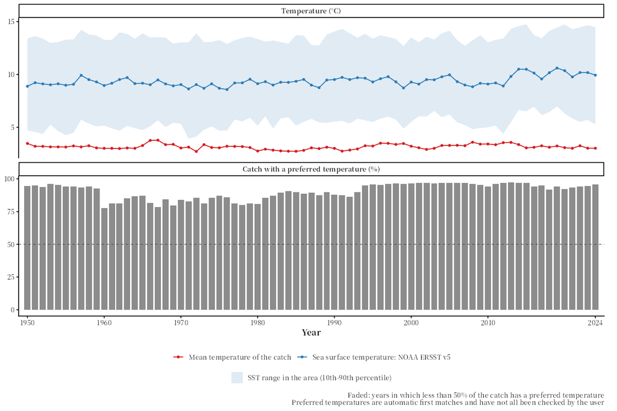

🔎 *How to read it.* The **mean temperature of the catch** (MTC, red) is the average preferred temperature of the species caught, weighted by their catch (Cheung et al. 2013); the blue line is the sea surface temperature (SST) of the area and the light band its range within the area. The lower panel is the share of the catch with a known preferred temperature; years below 50% are faded. A rising MTC means warm-water species take a larger share of the catch.

*What it shows for area 67.* The MTC stays between 2.7 and 3.8 °C, far below the SST of the area (9.9 °C in 2024). The reason is the species: the main catch is of cold-water fishes that live near the bottom, such as the pollock (preferred temperature 1.6 °C) and the Pacific cod (2.9 °C). The MTC was lowest in 1972, when the pollock gave 52% of the catch, and highest in 1967, before the pollock fishery grew; the Pacific hake of the US west coast (8.6 °C) raises it in the years when its catch is large. The trend of the MTC is “none” over 1950–2024 (0.009 °C per decade) and “none” over 1970–2024 (0.056 °C per decade) while the SST warmed by 0.21 °C per decade. The MTC of area 67 follows the mix of target species more than the ocean: read it with the species charts.

## 11. 📉 Stock assessment of the main species

`cmsy_area()` runs the CMSY++ catch-only stock assessment (Froese et al. 2023) for the species with the largest catch. It needs the JAGS program once (`cmsy_setup()`, see 📉 CMSY++) and takes a few minutes; the charts below were made beforehand with the same code.

```r
cmsy_setup()                                            # once: JAGS and the R packages
nep_cmsy <- cmsy_area("Pacific, Northeast", top = 10)   # the ten main species
nep_cmsy$summary                                        # B/Bmsy, F/Fmsy, MSY, status
```

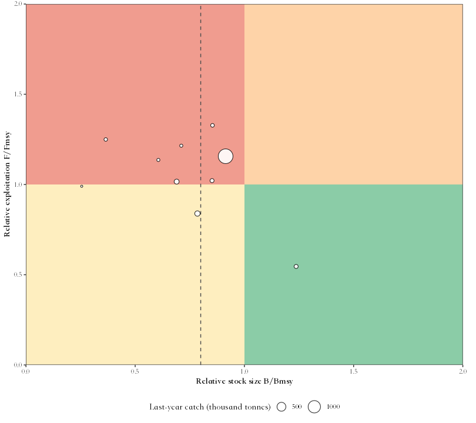

🔎 *How to read the Kobe plot.* Each circle is one stock in its last year: its biomass relative to the biomass that gives the maximum sustainable yield (B/Bmsy, horizontal) and its fishing pressure relative to the one that gives it (F/Fmsy, vertical); the size is the catch. Green (bottom right): healthy; red (top left): overfished and still overfishing; orange and yellow: one of the two. The dashed line at B/Bmsy = 0.8 separates “maximally sustainably fished” from “overfished” in the FAO classes for catch-only results.

*What it shows for area 67.* 6 of the 10 stocks assessed were below 0.8 Bmsy in their last year; the lowest were Pacific herring (0.26) and Pacific ocean perch (0.37), the two fisheries whose catch has fallen furthest from its peak.

| Stock | species | B_Bmsy | F_Fmsy | MSY | status |
| --- | --- | --- | --- | --- | --- |
| ALK_67 | Alaska pollock(=Walleye poll.) | 0.91 | 1.16 | 1,382,729 | maximally sustainably fished |
| NHA_67 | North Pacific hake | 0.69 | 1.02 | 268,082 | overfished |
| PCO_67 | Pacific cod | 0.78 | 0.84 | 266,781 | overfished |
| PIN_67 | Pink(=Humpback) salmon | 0.61 | 1.14 | 163,342 | overfished |
| HEP_67 | Pacific herring | 0.26 | 0.99 | 197,699 | overfished |
| SOC_67 | Sockeye(=Red) salmon | 0.85 | 1.02 | 134,004 | maximally sustainably fished |
| YES_67 | Yellowfin sole | 1.24 | 0.55 | 152,488 | maximally sustainably fished |
| OPP_67 | Pacific ocean perch | 0.37 | 1.25 | 191,429 | overfished |
| CHU_67 | Chum(=Keta=Dog) salmon | 0.71 | 1.21 | 59,817 | overfished |
| HUM_67 | Atka mackerel | 0.85 | 1.33 | 59,732 | maximally sustainably fished |

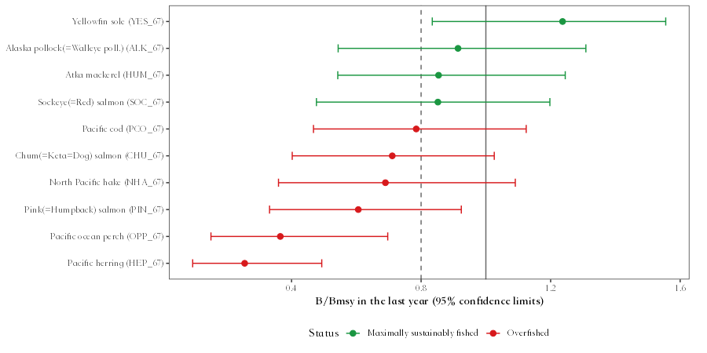

🔎 *How to read it.* One row per stock: its B/Bmsy in the last year with the 95% confidence limits (the bar), coloured by status. A long bar means the data could not pin the stock size down.

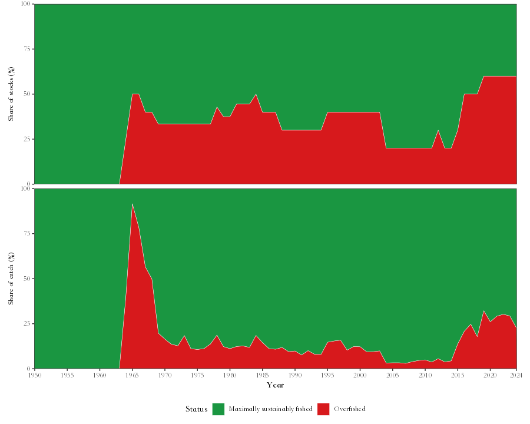

🔎 *How to read it.* The share of the assessed stocks in each status class, year by year. It shows whether the stocks of the area moved together, e.g. all declining in the same years.

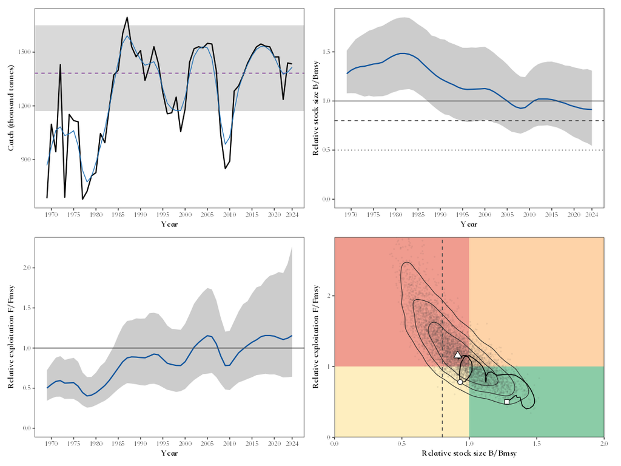

FAO capture statistics have no abundance index, so these are **catch-only** assessments driven largely by their priors: indicative only, never a replacement for a full stock assessment. This matters in area 67: most of its main stocks are assessed every year by the fishery agencies of the United States and Canada with survey data, and their catch is held by catch limits, so a catch that stays below its old peak can be read by a catch-only method as a smaller stock. Compare these results with the official assessments before using them. The CMSY++ code is that of its authors (https://github.com/SISTA16/cmsyPlusPlus); see the disclaimer in 📉 CMSY++.

## 12. 📝 The report in Word, LaTeX and PDF

`fao_report()` runs the analyses of the area and writes the whole assessment as a report: cover, abstract, data and methods, results with charts and tables, conclusions, references and appendix. Here a Word report in English, with the catch shocks and the mean temperature of the catch added to the default sections:

```r
report <- fao_report(67, lang = "en", shocks = TRUE, mtc = TRUE)
report
```

```
#> FAO report: /tmp/RtmpIm8Mqo/faofishingreport_site_20a852b71945d/reports/FAO67_report_en.docx
#> Sections: total, species, countries, groups, status, quality, diversity, fleets, shocks, mtc
#>   $main_species           main species of the last five years (10 rows)
#>   $main_countries         main fishing countries of the last five years (5 rows)
#>   $mtc_species            species of the mean temperature of the catch, with FishBase matches (200 rows)
#>   $analyses               results of the analyses: total, species, countries, groups, status, quality, diversity, fleets, shocks, mtc
```

The headings of the Word file:

```r
doc <- officer::docx_summary(officer::read_docx(report$file[["docx"]]))
headings <- doc$text[doc$style_name %in% c("FAO Heading 1", "FAO Heading 2")]
headings
```

```
#>  [1] "1 Data and methods"
#>  [2] "1.1 Data sources"
#>  [3] "1.2 Methods"
#>  [4] "2 Results and conclusions"
#>  [5] "2.1 Catch trends and stages"
#>  [6] "2.2 Main species"
#>  [7] "2.3 Main fishing countries"
#>  [8] "2.4 Composition by species group"
#>  [9] "2.5 Stock status"
#> [10] "2.6 Data quality"
#> [11] "2.7 Diversity and concentration of the catch"
#> [12] "2.8 Coastal and distant-water fleets"
#> [13] "2.9 Catch shocks"
#> [14] "2.10 Mean temperature of the catch"
#> [15] "2.11 Conclusions"
#> [16] "References"
#> [17] "Appendix"
```

### 12.1 Before the PDF: install TinyTeX once

The Word file and the LaTeX source (`format = "latex"`) need nothing else. The **PDF** is compiled from the LaTeX source with XeLaTeX, which comes with a LaTeX distribution. The simplest is [TinyTeX](https://yihui.org/tinytex/) (Xie 2019), a small distribution installed from R, without administrator rights:

```r
install.packages("tinytex")
tinytex::install_tinytex()   # once, a few minutes; restart R afterwards
tinytex::is_tinytex()        # TRUE when it is installed
```

The first PDF takes longer: TinyTeX downloads the LaTeX packages the report uses (e.g. `ctex` and the Chinese fonts for a Chinese report) and keeps them for the next times. If TinyTeX was installed long ago and the PDF fails with a message such as “TeX Live is older than remote”, update it with `tinytex::reinstall_tinytex()`. 📝 Assessment report lists the other cases (another LaTeX distribution, compiling an edited `.tex` file).

### 12.2 The same report as LaTeX and PDF

The same report as LaTeX and PDF, in Chinese, with CMSY++ (reusing the results of step 11 so CMSY++ does not run again):

```r
fao_report(67, lang = "zh", format = c("docx", "latex", "pdf"), shocks = TRUE, mtc = TRUE,
           cmsy = nep_cmsy)
```

| File | What it is |
| --- | --- |
| `reports/FAO67_report_en.docx` | The Word report, to edit and complete |
| `reports/FAO67_report_zh.tex` and `reports/FAO67_report_zh_figures/` | The LaTeX source and its figures |
| `reports/FAO67_report_zh.pdf` | The PDF (needs XeLaTeX, e.g. TinyTeX, see above) |

The report is a **first draft**: the text is written from templates filled with the results. Read it, complete the grey “To be completed” notes (other data sources, discussion, other references) and check every conclusion against the charts above. See 📝 Assessment report for every option.

## 13. 🗂️ Where everything is saved and how to get it back

Every function writes into the working directory:

| Folder | What | Written by |
| --- | --- | --- |
| `figures/png/` | `fishing_trend.png`, `fishing_percentage.png` | `fishing_area_data()` |
| `figures/png/area/` | `area_species*.png`, `area_country*.png` | `fishing_area_species()`, `fishing_area_country()` |
| `figures/png/` | `area_country_map.png`, `<species>_country_map.png` | maps of `fishing_area_country()`, `species_country()` |
| `figures/png/species/` | `<species>_country_*.png` | `species_country()` |
| `figures/png/country/` | `<country>_species_*.png`, `<country>analysis_*.png`, `<country>yearly_area_production*.png` | `country_species()`, `country_analysis()` |
| `figures/png/summary/` | `<label>_<analysis>*.png`, e.g. `Pacific__Northeast_stock_status_stocks.png` | the summary and literature analyses |
| `figures/pptx/...` | The same charts as PowerPoint files | when `pptx = TRUE` |
| `tables/` | CSV tables (UTF-8, open in Excel) | every function with `table = TRUE` |
| `reports/` | The reports, and `reports/cmsy/` with the CMSY++ results | `fao_report()` |
| `cmsy_areas/` | The CMSY++ runs, charts and tables of each area | `cmsy_area()` |

The files saved by this tutorial:

```r
head(list.files("figures/png", recursive = TRUE), 20)
```

```
#>  [1] "Alaska_pollock__Walleye_poll___country_map.png"
#>  [2] "area_country_map.png"
#>  [3] "area/area_country_wrap.png"
#>  [4] "area/area_country.png"
#>  [5] "area/area_species_wrap.png"
#>  [6] "area/area_species.png"
#>  [7] "country/United_States_of_America_species_pie_selected.png"
#>  [8] "country/United_States_of_America_species_ranked_total.png"
#>  [9] "country/United_States_of_America_species_ranked_wrap.png"
#> [10] "country/United_States_of_America_species_ranked.png"
#> [11] "country/United_States_of_Americaanalysis_area_total_production.png"
#> [12] "country/United_States_of_Americaanalysis_species_by_area.png"
#> [13] "country/United_States_of_Americaanalysis_species_pie_selected.png"
#> [14] "country/United_States_of_Americaanalysis_species_ranked_total.png"
#> [15] "country/United_States_of_Americaanalysis_species_ranked_wrap.png"
#> [16] "country/United_States_of_Americaanalysis_species_ranked.png"
#> [17] "country/United_States_of_Americafishing_area_map.png"
#> [18] "country/United_States_of_Americayearly_area_production_wrap.png"
#> [19] "country/United_States_of_Americayearly_area_production.png"
#> [20] "fishing_percentage.png"
```

```r
length(list.files("figures/png", recursive = TRUE))
```

```
#> [1] 65
```

```r
head(list.files("tables"), 10)
```

```
#>  [1] "Alaska_pollock__Walleye_poll___country_ranked_table.csv"
#>  [2] "area67_species_shocks_by_group.csv"
#>  [3] "area67_species_shocks_by_year.csv"
#>  [4] "area67_species_shocks_series.csv"
#>  [5] "area67_species_shocks.csv"
#>  [6] "country_coefs_data.csv"
#>  [7] "country_ranked_table.csv"
#>  [8] "Japan_distant_water_areas.csv"
#>  [9] "Japan_distant_water.csv"
#> [10] "marine_areas_peak_trend_area.csv"
```

**Getting results back.** Every function also returns its results to R (assign them, as above). To continue another day, save them and read them back, or read the CSV tables:

```r
saveRDS(list(NEP = NEP, status = status, mtc = mtc), "area67_results.rds")
results <- readRDS("area67_results.rds")
names(results)
```

```
#> [1] "NEP"    "status" "mtc"
```

```r
head(read.csv("tables/Pacific__Northeast_stock_status_stocks.csv"), 3)
```

```
#>                     species_name                     species_en first_year
#> 1 Alaska pollock(=Walleye poll.) Alaska pollock(=Walleye poll.)       1950
#> 2            Pacific ocean perch            Pacific ocean perch       1950
#> 3             North Pacific hake             North Pacific hake       1960
#>   peak_year peak_tonnes last_year_tonnes pct_of_peak status_last_year
#> 1      1987     1694473       1434351.99    84.64885        Exploited
#> 2      1965      460647         63974.28    13.88792       Rebuilding
#> 3      1987      372672        143562.00    38.52235   Over-exploited
```

When FAO publishes a new release, run `download_fao_data()` and the same code again: every chart, table and number is recomputed from the new data, and `fao_data_info()` gives the new citation.

## 14. 🎨 Make it yours

The same analyses in Chinese or bilingual charts, another style or map projection:

```r
fao_settings(lang = "zh")                  # Chinese charts and names
fao_settings(lang = "both")                # Chinese and English on the same chart
fao_settings(theme = "minimal", palette = "npg", map_projection = "robinson", map_center = 180)
fao_settings(reset = TRUE)                 # back to the defaults
```

See 🎨 Customise charts and maps for all settings.

## ✅ Summary

| Step | Function | Main output |
| --- | --- | --- |
| Data | `load_fao_data()`, `fao_data_info()` | The data and the release to cite |
| Area | `fishing_area_data()` | Total catch, stages, share of the world |
| Species, countries | `fishing_area_species()`, `fishing_area_country()`, `species_country()`, `country_species()`, `country_analysis()` | Who catches what, and its stages |
| Status | `species_group_composition()`, `stock_status()`, `peak_trend()`, `regime_shift()`, `area_overview()` | Composition, status, trends, shifts |
| Quality, fleets | `data_quality()`, `diversity_concentration()`, `country_group_summary()`, `coastal_distant()` | How reliable and how concentrated |
| Literature | `catch_shocks()`, `collapse_analysis()`, `catch_synchrony()`, `pelagic_demersal()`, `distant_water_profile()` | Shocks, collapses, synchrony, P/D, fleets |
| Temperature | `fishbase_match()`, `fao_area_sst()`, `mean_temperature_catch()` | Traits, SST, MTC |
| Assessment | `cmsy_area()` | B/Bmsy, F/Fmsy, MSY |
| Report | `fao_report()`, with TinyTeX for the PDF | Word, LaTeX, PDF |

## 📖 References

- Bai, J. and Perron, P. (2003). Computation and analysis of multiple structural change models. *Journal of Applied Econometrics*, 18(1), 1–22. [doi:10.1002/jae.659](https://doi.org/10.1002/jae.659)
- Caddy, J. F. (1993). Toward a comparative evaluation of human impacts on fishery ecosystems of enclosed and semi-enclosed seas. *Reviews in Fisheries Science*, 1(1), 57–95. [doi:10.1080/10641269309388535](https://doi.org/10.1080/10641269309388535)
- Cheung, W. W. L., Watson, R. and Pauly, D. (2013). Signature of ocean warming in global fisheries catch. *Nature*, 497, 365–368. [doi:10.1038/nature12156](https://doi.org/10.1038/nature12156)
- Cottrell, R. S., Nash, K. L., Halpern, B. S., Remenyi, T. A., Corney, S. P., Fleming, A., Fulton, E. A., Hornborg, S., Johne, A., Watson, R. A. and Blanchard, J. L. (2019). Food production shocks across land and sea. *Nature Sustainability*, 2, 130–137. [doi:10.1038/s41893-018-0210-1](https://doi.org/10.1038/s41893-018-0210-1)
- de Leiva Moreno, J. I., Agostini, V. N., Caddy, J. F. and Carocci, F. (2000). Is the pelagic-demersal ratio from fishery landings a useful proxy for nutrient availability? *ICES Journal of Marine Science*, 57(4), 1091–1102. [doi:10.1006/jmsc.2000.0705](https://doi.org/10.1006/jmsc.2000.0705)
- FAO. 2026. Global Capture Production 1950-2024, release 2026.1.0. In: Fisheries and Aquaculture [online]. Rome. [Cited 10 October 2026]. https://www.fao.org/fishery/collection/capture/en. Licence: CC BY 4.0.
- Fishery Conservation and Management Act of 1976. Public Law 94-265, 90 Stat. 331, United States (in force 1 March 1977; now the Magnuson-Stevens Fishery Conservation and Management Act).
- Froese, R., Winker, H., Coro, G., Palomares, M. L. D., Tsikliras, A. C., Dimarchopoulou, D., Touloumis, K., Demirel, N., Vianna, G. M. S., Scarcella, G., Schijns, R., Liang, C. and Pauly, D. (2023). New developments in the analysis of catch time series as the basis for fish stock assessments: the CMSY++ method. *Acta Ichthyologica et Piscatoria*, 53, 173–189. [doi:10.3897/aiep.53.105910](https://doi.org/10.3897/aiep.53.105910)
- Hare, S. R. and Mantua, N. J. (2000). Empirical evidence for North Pacific regime shifts in 1977 and 1989. *Progress in Oceanography*, 47(2–4), 103–145. doi:10.1016/S0079-6611(00)00033-1
- Kleisner, K., Zeller, D., Froese, R. and Pauly, D. (2013). Using global catch data for inferences on the world’s marine fisheries. *Fish and Fisheries*, 14(3), 293–311. [doi:10.1111/j.1467-2979.2012.00469.x](https://doi.org/10.1111/j.1467-2979.2012.00469.x)
- Loreau, M. and de Mazancourt, C. (2008). Species synchrony and its drivers: neutral and nonneutral community dynamics in fluctuating environments. *The American Naturalist*, 172(2), E48–E66. [doi:10.1086/589746](https://doi.org/10.1086/589746)
- Mullon, C., Fréon, P. and Cury, P. (2005). The dynamics of collapse in world fisheries. *Fish and Fisheries*, 6(2), 111–120. [doi:10.1111/j.1467-2979.2005.00181.x](https://doi.org/10.1111/j.1467-2979.2005.00181.x)
- Swartz, W., Sala, E., Tracey, S., Watson, R. and Pauly, D. (2010). The spatial expansion and ecological footprint of fisheries (1950 to present). *PLoS ONE*, 5(12), e15143. [doi:10.1371/journal.pone.0015143](https://doi.org/10.1371/journal.pone.0015143)
- Wilberg, M. J. and Miller, T. J. (2007). Comment on “Impacts of biodiversity loss on ocean ecosystem services”. *Science*, 316, 1285. [doi:10.1126/science.1137946](https://doi.org/10.1126/science.1137946)
- Xie, Y. (2019). TinyTeX: a lightweight, cross-platform, and easy-to-maintain LaTeX distribution based on TeX Live. *TUGboat*, 40(1), 30–32. https://tug.org/TUGboat/tb40-1/tb124xie-tinytex.pdf; R package tinytex: https://CRAN.R-project.org/package=tinytex